# Census Lab 2: Bivariate Maps and Change Over Time

Ethan Crookshank

This chunk contains the necessary packages that will be used as well as the API key needed to fetch census data.

```r
# Loading all of the packages that we need and using the API key to fetch census data

# packages
library(tidyverse)
library(tidycensus)
library(sf)
library(ggplot2)
# settings for tidycensus
options(tigris_class = "sf")
options(tigris_use_cache = TRUE)
census_api_key("937eed644b7bc41f3ae13d18f51a459a4ac85100")
```

```
To install your API key for use in future sessions, run this function with `install = TRUE`.
```

Part 1: Single Variable Change over Time

The first task is to show change over time for one variable. To do this, we need to create two variables containing data from the same census dataset but from two different years. We will be using 2015 and 2019 as our two years. The data we will be using is median gross rent as a percentage of income, essentially a measure of how expensive rent is in an area relative to average income levels in that region.

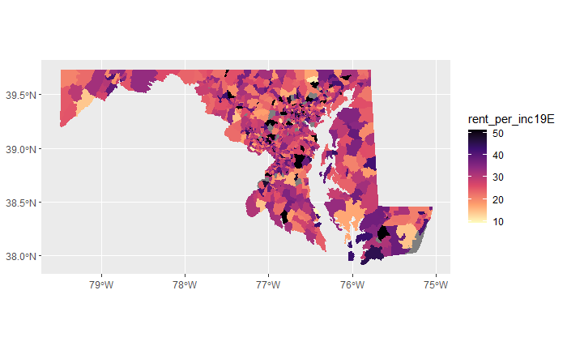

```r
#This is a map of median gross rent divided by income by tract for MD
rent_per_inc_2019 <- get_acs(geography = "tract",
     variables = c("rent_per_inc19"="B25071_001"),
     year = 2019,
     survey = "acs5",
     state =" MD",

     geometry = TRUE, # download the shapefile with the data
     output = "wide") # need this
rent_per_inc_2019 <- st_transform(rent_per_inc_2019, 3857)


rent_per_inc_2019 %>% ggplot(aes(fill=rent_per_inc19E, color=rent_per_inc19E))+
  geom_sf() +
  coord_sf(crs=3857) + # Web Mercator 3857, or UTM 18N for Maryland 26918
  scale_fill_viridis_c(option="magma", direction=-1) +
  scale_color_viridis_c(option="magma", direction=-1)
```

We can use the same code for the 2015 data just by swapping 2019 out for 2015 in the variable names and the year= portion of the census data fetch function.

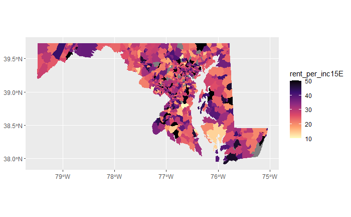

```r
#This is a map of median gross rent divided by income by tract for MD
rent_per_inc_2015 <- get_acs(geography = "tract",
     variables = c("rent_per_inc15"="B25071_001"),
     year = 2015,
     survey = "acs5",
     state =" MD",

     geometry = TRUE, # download the shapefile with the data
     output = "wide") # need this
rent_per_inc_2015 <- st_transform(rent_per_inc_2015, 3857)


rent_per_inc_2015 %>% ggplot(aes(fill=rent_per_inc15E, color=rent_per_inc15E))+
  geom_sf() +
  coord_sf(crs=3857) + # Web Mercator 3857, or UTM 18N for Maryland 26918
  scale_fill_viridis_c(option="magma", direction=-1) +
  scale_color_viridis_c(option="magma", direction=-1)
```

Now that we have data for the two time periods, we can find the change by subtracting the data for 2015 from the data for 2019, and writing the results onto a new variable. We then plot this new variable to ensure that it is different from the prior two maps, which would indicate that the code worked.

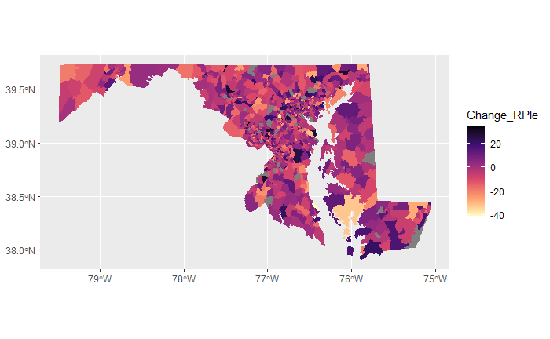

```r
Change_Over_Time <- rent_per_inc_2019
Change_Over_Time$Change_RPIe <- rent_per_inc_2019$rent_per_inc19E - rent_per_inc_2015$rent_per_inc15E
Change_Over_Time$rent_per_inc19E<- NULL
Change_Over_Time$rent_per_inc19M<- NULL

#This is not the most elegant way of doing this but it works.

Change_Over_Time %>% ggplot(aes(fill=Change_RPIe, color=Change_RPIe))+
  geom_sf() +
  coord_sf(crs=3857) + # Web Mercator 3857, or UTM 18N for Maryland 26918
  scale_fill_viridis_c(option="magma", direction=-1) +
  scale_color_viridis_c(option="magma", direction=-1)
```

```r
NA
NA
NA
```

Once satisfied with the data, we can write it to a Shapefile for manipulation in QGIS

```r
#st_write(Change_Over_Time, "Percent Income Towards Rent.SHP")
```

Part 2: Bivariate Change over Time

In order to make a bivariate change over time map, we need to merge two sets of data. This can be done before or after subtracting to find change over time, but would be simpler to do afterwards as we already have a finished change over time variable from part 1 that we can use.

The first step, as before, is to identify a dataset and check how it looks in the two time periods we are working in, 2015 and 2019.

The dataset that we will be using for this step is number of renting households with incomes below the poverty line. This dataset was chosen because it could potentially reveal some interesting patterns when viewed as a bivariate map with the previous dataset, as it is not difficult to imagine a relationship between areas with high rents relative to income and areas with high numbers of renters living below the poverty line.

As before we fetch and map the desired data twice, once for 2019 as shown here

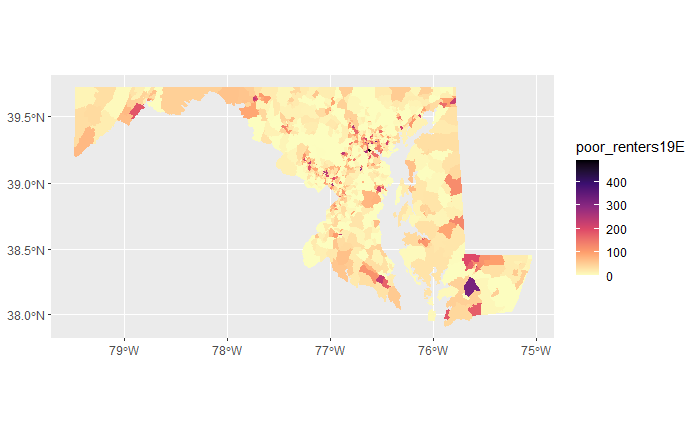

```r
#An estimate of renting households below the poverty line in 2019 made by summing the data sets within "poverty level by household type by tenure" that fit the constraints of being both below the poverty level and being renter occupied.


#This is the data for Renter occupied households with income in the past 12 months below poverty level that contain Married-couple families

Poor_renters_2019_1 <- get_acs(geography = "tract",
     variables = c("poor_renters19_1"="B17019_005"),
     year = 2019,
     survey = "acs5",
     state =" MD",

     geometry = TRUE, # download the shapefile with the data
     output = "wide") # need this
Poor_renters_2019_1 <- st_transform(Poor_renters_2019_1, 3857)



#This is the data for Renter occupied households with income in the past 12 months below poverty level that contain a male householder, and no wife present

Poor_renters_2019_2 <- get_acs(geography = "tract",
     variables = c("poor_renters19_2"="B17019_009"),
     year = 2019,
     survey = "acs5",
     state =" MD",

     geometry = TRUE, # download the shapefile with the data
     output = "wide") # need this
Poor_renters_2019_2 <- st_transform(Poor_renters_2019_2, 3857)


#This is the data for Renter occupied households with income in the past 12 months below poverty level that contain a female householder, no husband present

Poor_renters_2019_3 <- get_acs(geography = "tract",
     variables = c("poor_renters19_3"="B17019_012"),
     year = 2019,
     survey = "acs5",
     state =" MD",

     geometry = TRUE, # download the shapefile with the data
     output = "wide") # need this
Poor_renters_2019_3 <- st_transform(Poor_renters_2019_3, 3857)

#Here we create a variable for the aggregate data set. I set it to match the Poor_renters_2019_1 dataset initially so ensure that the GEOID, NAME, and Geometry columns are correct, and then delete the extraneous columns by setting the, as NULL
Poor_renters_2019 <- Poor_renters_2019_1
Poor_renters_2019$poor_renters19_1E <- NULL
Poor_renters_2019$poor_renters19_1M <- NULL

#Here we create the column poor_renters19E by summing the 3 component categories
Poor_renters_2019$poor_renters19E <- Poor_renters_2019_1$poor_renters19_1E + Poor_renters_2019_2$poor_renters19_2E + Poor_renters_2019_3$poor_renters19_3E

#Plotting the data to check for gaps, obvious problems
Poor_renters_2019 %>% ggplot(aes(fill=poor_renters19E, color=poor_renters19E))+
  geom_sf() +
  coord_sf(crs=3857) + # Web Mercator 3857, or UTM 18N for Maryland 26918
  scale_fill_viridis_c(option="magma", direction=-1) +
  scale_color_viridis_c(option="magma", direction=-1)
```

And again for 2015, as shown here.

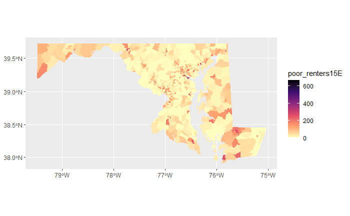

```r
#An estimate of renting households below the poverty line in 2015 made by summing the data sets within "poverty level by household type by tenure" that fit the constraints of being both below the poverty level and being renter occupied.


#This is the data for Renter occupied households with income in the past 12 months below poverty level that contain Married-couple families

Poor_renters_2015_1 <- get_acs(geography = "tract",
     variables = c("poor_renters15_1"="B17019_005"),
     year = 2015,
     survey = "acs5",
     state =" MD",

     geometry = TRUE, # download the shapefile with the data
     output = "wide") # need this
Poor_renters_2015_1 <- st_transform(Poor_renters_2015_1, 3857)



#This is the data for Renter occupied households with income in the past 12 months below poverty level that contain a male householder, and no wife present

Poor_renters_2015_2 <- get_acs(geography = "tract",
     variables = c("poor_renters15_2"="B17019_009"),
     year = 2015,
     survey = "acs5",
     state =" MD",

     geometry = TRUE, # download the shapefile with the data
     output = "wide") # need this
Poor_renters_2015_2 <- st_transform(Poor_renters_2015_2, 3857)



#This is the data for Renter occupied households with income in the past 12 months below poverty level that contain a female householder, no husband present

Poor_renters_2015_3 <- get_acs(geography = "tract",
     variables = c("poor_renters15_3"="B17019_012"),
     year = 2015,
     survey = "acs5",
     state =" MD",

     geometry = TRUE, # download the shapefile with the data
     output = "wide") # need this
Poor_renters_2015_3 <- st_transform(Poor_renters_2015_3, 3857)


#Here we create a variable for the aggregate data set. I set it to match the Poor_renters_2015_1 dataset initially so ensure that the GEOID, NAME, and Geometry columns are correct, and then delete the extraneous columns by setting the, as NULL


Poor_renters_2015 <- Poor_renters_2015_1
Poor_renters_2015$poor_renters15_1E <- NULL
Poor_renters_2015$poor_renters15_1M <- NULL

#Here we create the column poor_renters15E by summing the 3 component categories

Poor_renters_2015$poor_renters15E <- Poor_renters_2015_1$poor_renters15_1E + Poor_renters_2015_2$poor_renters15_2E + Poor_renters_2015_3$poor_renters15_3E

#Checking for errors, gaps by plotting
Poor_renters_2015 %>% ggplot(aes(fill=poor_renters15E, color=poor_renters15E))+
  geom_sf() +
  coord_sf(crs=3857) + # Web Mercator 3857, or UTM 18N for Maryland 26918
  scale_fill_viridis_c(option="magma", direction=-1) +
  scale_color_viridis_c(option="magma", direction=-1)
```

As there does not seem to be any major gaps in the data, it is time to create our second change over time variable. We will accomplish this exactly as we did earlier.

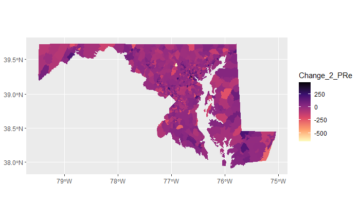

```r
Change_Over_Time2 <- Poor_renters_2019
Change_Over_Time2$Change_2_PRe <- Poor_renters_2019$poor_renters19E - Poor_renters_2015$poor_renters15E
Change_Over_Time2$poor_renters19E<- NULL
Change_Over_Time2$poor_renters19M<- NULL

#This is not the most elegant way of doing this but it works.

Change_Over_Time2 %>% ggplot(aes(fill=Change_2_PRe, color=Change_2_PRe))+
  geom_sf() +
  coord_sf(crs=3857) + # Web Mercator 3857, or UTM 18N for Maryland 26918
  scale_fill_viridis_c(option="magma", direction=-1) +
  scale_color_viridis_c(option="magma", direction=-1)
```

```r
NA
NA
NA
```

With both Change over time datasets finished, we can now merge them with a left join and save the result to a shapefile for use in QGIS

```r
Joined_Changes <- st_join(Change_Over_Time, Change_Over_Time2, join = st_intersects, left = TRUE,  largest = FALSE)



st_write(Joined_Changes, "Bivariate_Change3.shp")
```

```
Field names abbreviated for ESRI Shapefile driver
```

```
Writing layer `Bivariate_Change3' to data source `Bivariate_Change3.shp' using driver `ESRI Shapefile'
Writing 9854 features with 6 fields and geometry type Multi Polygon.
```